# 13. 다양한 그래프

이번 장에서는 특정 범주에 속하지 않는 여러 가지 시각화 자료를 만든다.

### A. 상관 계수 행렬(correlation matrix)

> 13.1 상관 계수 행렬 만들기

### B. 함수의 그래프

> 13.2 함수를 그래프로 그리기  
> 13.3 함수 곡선 아래의 영역 일부분에 음영 넣기

### C. 네트워크 그래프(network graph)

> 13.4 네트워크 그래프 그리기  
> 13.5 네트워크 그래프에 텍스트 라벨 넣기

### D. 히트맵(heatmap)

> 13.6 히트맵 생성하기

### E. 삼차원 산점도(3D scatterplot)

> 13.7 삼차원 산점도 생성하기  
> 13.8 삼차원 그래프에 예측면 추가하기  
> 13.9 삼차원 그래프 저장하기  
> 13.10 삼차원 그래프에 애니메이션 넣기

### F. 덴드로그램(dendrogram)

> 13.11 덴드로그램 생성하기

### G. 벡터장(vector field)

> 13.12 벡터장 그리기

### H. 통계치의 그래프

> 13.13 Q-Q 그래프 그리기  
> 13.14 경험적 누적 분포 함수 그래프 그리기  
> 13.15 모자이크 그래프 그리기  
> 13.16 파이 차트 만들기

### I. 지도(map)

> 13.17 지도 그리기  
> 13.18 단계 구분도(Choropleth Map) 만들기  
> 13.19 배경이 깨끗한 지도 만들기  
> 13.20 Shapefile로부터 지도 만들기

필요한 패키지와 라이브러리 설치

```r
#install.packages("knitr")
#install.packages("markdown")
#install.packages("ggplot2")
#install.packages("gcookbook")
#install.packages("corrplot")
#install.packages("igraph")
#install.packages("rgl")
#install.packages("vcd")
#install.packages("grid")
#install.packages("maps")
#install.packages("mapproj")
#install.packages("maptools")
library(knitr)
library(markdown)
library(ggplot2)
library(gcookbook)
library(corrplot)
library(igraph)
library(rgl)
library(vcd)
library(grid)
library(maps)
library(mapproj)
library(maptools)
```

# A. 상관 계수 행렬(correlation matrix)

### 13.1 상관 계수 행렬 만들기

상관 계수 행렬(correlation matrix)를 만들려면  
cor를 사용해 숫자로 된 상관 계수 행렬을 생성한 다음  
열(column)을 두 개씩 묶은 각 쌍들에 대해 상관 계수를 생성해준다.

```r
# mtcars데이터 보기
mtcars
```

```
##                      mpg cyl  disp  hp drat    wt  qsec vs am gear carb
## Mazda RX4           21.0   6 160.0 110 3.90 2.620 16.46  0  1    4    4
## Mazda RX4 Wag       21.0   6 160.0 110 3.90 2.875 17.02  0  1    4    4
## Datsun 710          22.8   4 108.0  93 3.85 2.320 18.61  1  1    4    1
## Hornet 4 Drive      21.4   6 258.0 110 3.08 3.215 19.44  1  0    3    1
## Hornet Sportabout   18.7   8 360.0 175 3.15 3.440 17.02  0  0    3    2
## Valiant             18.1   6 225.0 105 2.76 3.460 20.22  1  0    3    1
## Duster 360          14.3   8 360.0 245 3.21 3.570 15.84  0  0    3    4
## Merc 240D           24.4   4 146.7  62 3.69 3.190 20.00  1  0    4    2
## Merc 230            22.8   4 140.8  95 3.92 3.150 22.90  1  0    4    2
## Merc 280            19.2   6 167.6 123 3.92 3.440 18.30  1  0    4    4
## Merc 280C           17.8   6 167.6 123 3.92 3.440 18.90  1  0    4    4
## Merc 450SE          16.4   8 275.8 180 3.07 4.070 17.40  0  0    3    3
## Merc 450SL          17.3   8 275.8 180 3.07 3.730 17.60  0  0    3    3
## Merc 450SLC         15.2   8 275.8 180 3.07 3.780 18.00  0  0    3    3
## Cadillac Fleetwood  10.4   8 472.0 205 2.93 5.250 17.98  0  0    3    4
## Lincoln Continental 10.4   8 460.0 215 3.00 5.424 17.82  0  0    3    4
## Chrysler Imperial   14.7   8 440.0 230 3.23 5.345 17.42  0  0    3    4
## Fiat 128            32.4   4  78.7  66 4.08 2.200 19.47  1  1    4    1
## Honda Civic         30.4   4  75.7  52 4.93 1.615 18.52  1  1    4    2
## Toyota Corolla      33.9   4  71.1  65 4.22 1.835 19.90  1  1    4    1
## Toyota Corona       21.5   4 120.1  97 3.70 2.465 20.01  1  0    3    1
## Dodge Challenger    15.5   8 318.0 150 2.76 3.520 16.87  0  0    3    2
## AMC Javelin         15.2   8 304.0 150 3.15 3.435 17.30  0  0    3    2
## Camaro Z28          13.3   8 350.0 245 3.73 3.840 15.41  0  0    3    4
## Pontiac Firebird    19.2   8 400.0 175 3.08 3.845 17.05  0  0    3    2
## Fiat X1-9           27.3   4  79.0  66 4.08 1.935 18.90  1  1    4    1
## Porsche 914-2       26.0   4 120.3  91 4.43 2.140 16.70  0  1    5    2
## Lotus Europa        30.4   4  95.1 113 3.77 1.513 16.90  1  1    5    2
## Ford Pantera L      15.8   8 351.0 264 4.22 3.170 14.50  0  1    5    4
## Ferrari Dino        19.7   6 145.0 175 3.62 2.770 15.50  0  1    5    6
## Maserati Bora       15.0   8 301.0 335 3.54 3.570 14.60  0  1    5    8
## Volvo 142E          21.4   4 121.0 109 4.11 2.780 18.60  1  1    4    2
```

```r
# cor를 사용해 열(column)을 두 개씩 묶은 각 쌍들의 상관 계수 행렬을 생성
mcor <- cor(mtcars)
mcor
```

```
##          mpg     cyl    disp      hp     drat      wt    qsec      vs
## mpg   1.0000 -0.8522 -0.8476 -0.7762  0.68117 -0.8677  0.4187  0.6640
## cyl  -0.8522  1.0000  0.9020  0.8324 -0.69994  0.7825 -0.5912 -0.8108
## disp -0.8476  0.9020  1.0000  0.7909 -0.71021  0.8880 -0.4337 -0.7104
## hp   -0.7762  0.8324  0.7909  1.0000 -0.44876  0.6587 -0.7082 -0.7231
## drat  0.6812 -0.6999 -0.7102 -0.4488  1.00000 -0.7124  0.0912  0.4403
## wt   -0.8677  0.7825  0.8880  0.6587 -0.71244  1.0000 -0.1747 -0.5549
## qsec  0.4187 -0.5912 -0.4337 -0.7082  0.09120 -0.1747  1.0000  0.7445
## vs    0.6640 -0.8108 -0.7104 -0.7231  0.44028 -0.5549  0.7445  1.0000
## am    0.5998 -0.5226 -0.5912 -0.2432  0.71271 -0.6925 -0.2299  0.1683
## gear  0.4803 -0.4927 -0.5556 -0.1257  0.69961 -0.5833 -0.2127  0.2060
## carb -0.5509  0.5270  0.3950  0.7498 -0.09079  0.4276 -0.6562 -0.5696
##            am    gear     carb
## mpg   0.59983  0.4803 -0.55093
## cyl  -0.52261 -0.4927  0.52699
## disp -0.59123 -0.5556  0.39498
## hp   -0.24320 -0.1257  0.74981
## drat  0.71271  0.6996 -0.09079
## wt   -0.69250 -0.5833  0.42761
## qsec -0.22986 -0.2127 -0.65625
## vs    0.16835  0.2060 -0.56961
## am    1.00000  0.7941  0.05753
## gear  0.79406  1.0000  0.27407
## carb  0.05753  0.2741  1.00000
```

```r
# mcor를 출력하고 2자리로 반올림
round(mcor, digits=2)
```

```
##        mpg   cyl  disp    hp  drat    wt  qsec    vs    am  gear  carb
## mpg   1.00 -0.85 -0.85 -0.78  0.68 -0.87  0.42  0.66  0.60  0.48 -0.55
## cyl  -0.85  1.00  0.90  0.83 -0.70  0.78 -0.59 -0.81 -0.52 -0.49  0.53
## disp -0.85  0.90  1.00  0.79 -0.71  0.89 -0.43 -0.71 -0.59 -0.56  0.39
## hp   -0.78  0.83  0.79  1.00 -0.45  0.66 -0.71 -0.72 -0.24 -0.13  0.75
## drat  0.68 -0.70 -0.71 -0.45  1.00 -0.71  0.09  0.44  0.71  0.70 -0.09
## wt   -0.87  0.78  0.89  0.66 -0.71  1.00 -0.17 -0.55 -0.69 -0.58  0.43
## qsec  0.42 -0.59 -0.43 -0.71  0.09 -0.17  1.00  0.74 -0.23 -0.21 -0.66
## vs    0.66 -0.81 -0.71 -0.72  0.44 -0.55  0.74  1.00  0.17  0.21 -0.57
## am    0.60 -0.52 -0.59 -0.24  0.71 -0.69 -0.23  0.17  1.00  0.79  0.06
## gear  0.48 -0.49 -0.56 -0.13  0.70 -0.58 -0.21  0.21  0.79  1.00  0.27
## carb -0.55  0.53  0.39  0.75 -0.09  0.43 -0.66 -0.57  0.06  0.27  1.00
```

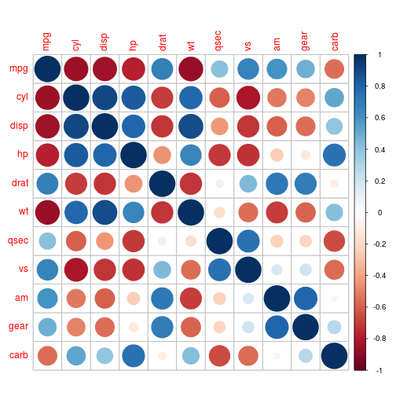

```r
# 상관 행렬을 그리는데 필요한 패키지를 설치
#install.packages("corrplot")
library(corrplot)

# 상관 행렬 그리기(기본형)
corrplot(mcor)
```

[figure not shown]

```r
# corrplot() 함수의 응용

# 사각형에 라벨을 회전
corrplot(mcor, method="shade", shade.col=NA, tl.col="black", tl.srt=45)
```

[output not shown]

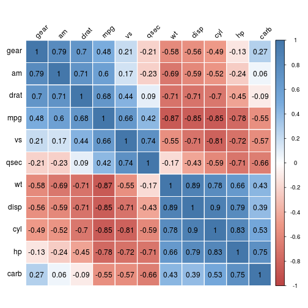

```r
# 사각형에 상관 계수를 표시하는 라벨을 넣기 위해 옅은 색의 팔레트를 생성
col <- colorRampPalette(c("#BB4444", "#EE9988", "#FFFFFF", "#77AADD", "#4477AA"))

# 상관관계가 큰 항목들이 함께 모이도록 order=AOE(angular order of eigenvectors) 사용
corrplot(mcor, method="shade", shade.col=NA, tl.col="black", tl.srt=45,
         col=col(200), addCoef.col="black", addcolorlabel="no", order="AOE")
```

- corrplot() 함수의 몇 가지 유용한 옵션들

| 옵션 | 설명 |
| --- | --- |
| type=“lower”,“upper” | 위쪽 또는 아래쪽 삼각형만 사용 |
| diag=FALSE | 대각선에는 값을 보여주지 않음 |
| addshade=“all” | 상관관계의 방향을 보여주는 선을 추가 |
| shade.col=NA | 상관관계 방향선을 숨김 |
| method=“shade” | 색을 입힌 사각형을 사용 |
| method=“elipse” | 타원을 사용 |
| addCoef.col=“color” | 색깔이 있는 상관계수를 삽입 |
| tl.srt=“number” | 위쪽 라벨의 회전 각도를 지정 |
| tl.col=“color” | 라벨 색깔을 지정 |
| order=“AOE”,“FPC”,“hclust” | 고유벡터의 각도 순(angular order of eigenvectors), 제 1 주성분(first principle component) 또는 계층적 군집 분석(hierarchical clustering)을 사용해 라벨을 정렬 |

# B. 함수의 그래프

### 13.2 함수를 그래프로 그리기

어떤 함수를 그래프로 그릴 때 stat_function()을 사용 예제로 정규 분포의 밀도를 반환해 주는 dnorm() 함수

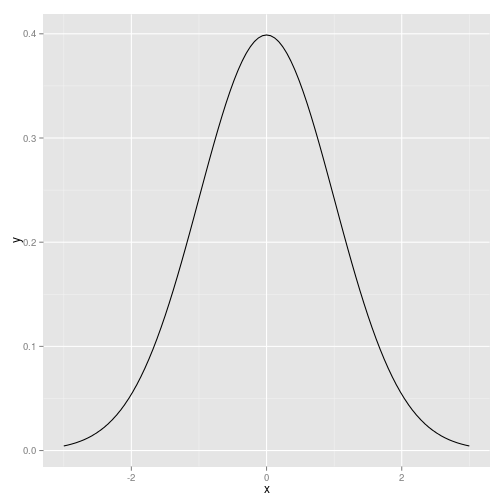

```r
# ggplot()에 가짜로 데이터 프레임을 하나 전달하여
# x범위를 제대로 인식하도록 하기 위해
# 데이터 프레임을 범위를 설정하는 데에만 사용
p <- ggplot(data.frame(x=c(-3,3)), aes(x=x))

# 정규 분포 밀도 함수
p + stat_function(fun = dnorm)
```

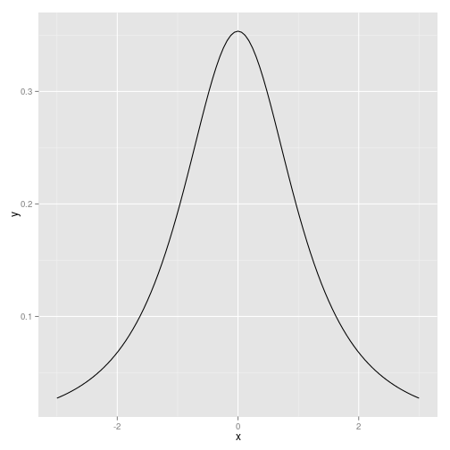

```r
# 자유도가 2인  t분포 함수(추가적인 인자들은 리스트에 넣어 args로 함수에 전달)
p + stat_function(fun=dt, args=list(df=2))
```

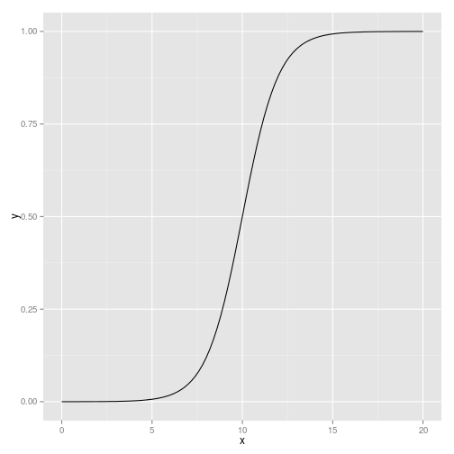

```r
# 사용자 정의 함수(예제 : 시그모이드 함수sigmoid function)
myfun <- function(xvar) {
    1/(1 + exp(-xvar + 10))
}
ggplot(data.frame(x=c(0, 20)), aes(x=x)) + stat_function(fun=myfun)
```

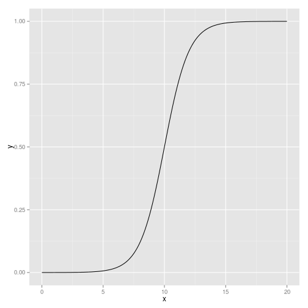

```r
# 기본 설정은  x범위상의 101개 점에서 계산되므로 곡선을 부드럽게 하려면  n값을 크게 함.
ggplot(data.frame(x=c(0, 20)), aes(x=x)) + stat_function(fun=myfun, n=200)
```

### 13.3 함수 곡선 아래의 영역 일부분에 음영 넣기

함수 곡선 아래의 영역 일부에 음영을 넣으려면,  
함수 주위로 새로운 래퍼 함수를 정의하고 범위 밖의 값들을 NA()로 대체.

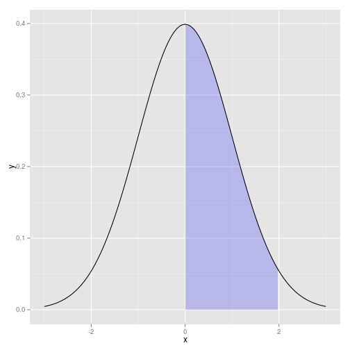

```r
# 0 < x < 2에 대해 dnorm(x)을 반환하고, 다른 모든 x에 대해 NA를 반환
dnorm_limit <- function(x) {
    y <- dnorm(x)
    y[x < 0  |  x > 2] <- NA
    return(y)
}

# 가짜 데이터를 ggplot()에 넣음(이 함수에 전달되는 것은 개별 값이 아닌 벡터)
p <- ggplot(data.frame(x=c(-3, 3)), aes(x=x))
p + stat_function(fun=dnorm_limit, geom="area", fill="blue", alpha=0.2) +
    stat_function(fun=dnorm)
```

R에는 일급 함수(first-class function)이 있어 클로저(closure) 반환 함수를 만들게 해줌.  
즉, 또 다른 함수를 프로그래밍하는 함수를 프로그래밍할 수 있다는 뜻.  
예를 들어 아래의서 limitRange()와 같은 함수를 만들어두면  
어떤 함수든 해당 함수의 한정된 범위 버전을 만들기 위해 사용할 수 있으므로 재사용이 간단해짐.

```r
# 함수, 최솟값, 최댓값을 전달하는 함수(범위 밖의 값들은 NA 로 반환)
limitRange <- function(fun, min, max) {
    function(x) {
        y <- fun(x)
        y[x < min  |  x > max] <- NA
        return(y)
    }
}
```

```r
# 이 함수를 호출해서 다른 함수를 행성(앞서 사용한  dnorm_limit()와 실질적으로 동일)
dlimit <- limitRange(dnorm, 0, 2)

# 새 함수를 시험해보면 -2부터 4의 값을 입력하면 0부터 2의 입력에 대한 값만 반환
dlimit(-2:4)
```

```
## [1]      NA      NA 0.39894 0.24197 0.05399      NA      NA
```

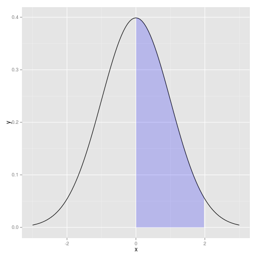

```r
# limitRange() 함수를 사용해 stat_function() 에 전달할 함수를 생성
p + stat_function(fun = dnorm) +
    stat_function(fun = limitRange(dnorm, 0, 2),
                  geom="area", fill="blue", alpha=0.2)
```

# C. 네트워크 그래프(network graph)

### 13.4 네트워크 그래프 그리기

네트워크 그래프를 그리려면 igraph 패키지를 사용하여  
항목 쌍들을 담고 있는 벡터를 graph()에 전달한 다음 결과 객체를 그래프로 그림

- 주의 : 상황에 따라 달라지는 값들을 고정된 값으로 매번 코딩하면 유연성이 떨어짐

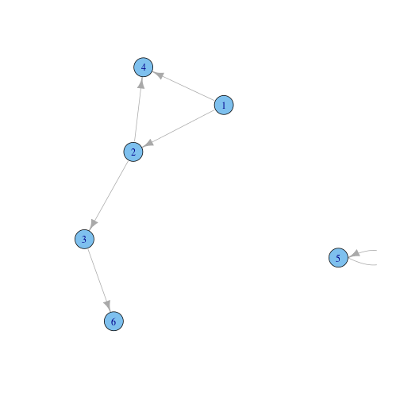

```r
# igraph 패키지를 설치
#install.packages("igraph")
library(igraph)

# 방향이 있는(directed) 그래프를 만들 때 연결선(edge)를 지정
gd <- graph(c(1,2, 2,3, 2,4, 1,4, 5,5, 3,6))
plot(gd)
```

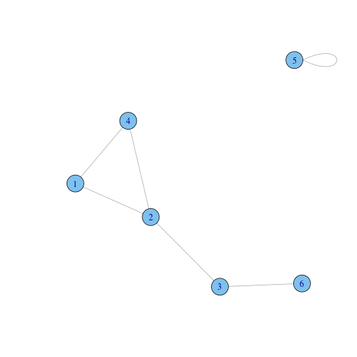

```r
# 방향이 없는(undirected graph) 그래프
gu <- graph(c(1,2, 2,3, 2,4, 1,4, 5,5, 3,6), directed=FALSE)
plot(gu)
```

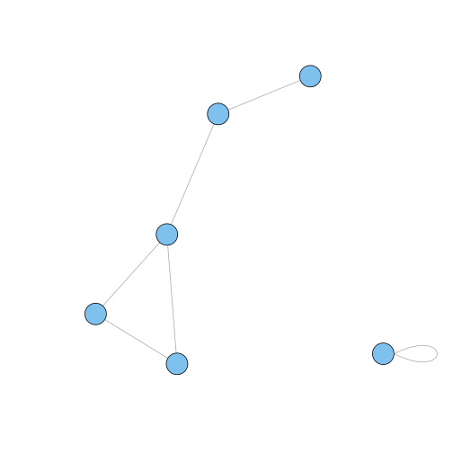

```r
# 라벨을 제거
plot(gu, vertex.label=NA)
```

```r
# 각 그래프 객체의 구조 확인
str(gd)
```

```
## IGRAPH D--- 6 6 --
## + edges:
## [1] 1->2 2->3 2->4 1->4 5->5 3->6
```

```r
str(gu)
```

```
## IGRAPH U--- 6 6 --
## + edges:
## [1] 1--2 2--3 2--4 1--4 5--5 3--6
```

네트워크 그래프에서 노드(node)의 위치는 데이터에서 지정하는 것이 아니고 랜덤하게 분포.  
똑같은 출력을 반복하려면 그래프를 만들기 전에 랜덤 시드를 설정해야함.

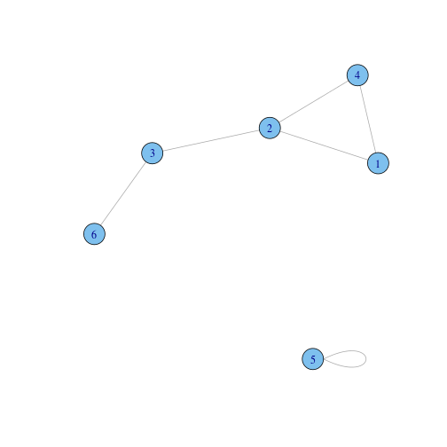

```r
# 시드 설정
set.seed(229)
plot(gu)
```

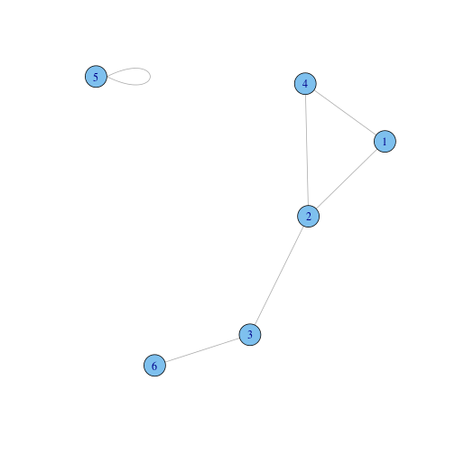

```r
set.seed(100)
plot(gu)
```

데이터 프레임으로부터 그래프를 생성하는 것도 가능.  
데이터 프레임의 맨 앞 두 열이 사용되고, 각 행은 두 노드 사이의 연결을 의미.

```r
library(gcookbook)
head(madmen2, 10)
```

```
##                       Name1         Name2
## 1               Abe Drexler   Peggy Olson
## 2                   Allison    Don Draper
## 3               Arthur Case  Betty Draper
## 4      Bellhop in Baltimore    Sal Romano
## 5          Bethany Van Nuys    Don Draper
## 6              Betty Draper    Don Draper
## 7              Betty Draper Henry Francis
## 8              Betty Draper    Random guy
## 9            Bobbie Barrett    Don Draper
## 10 Brooklyn College Student   Peggy Olson
```

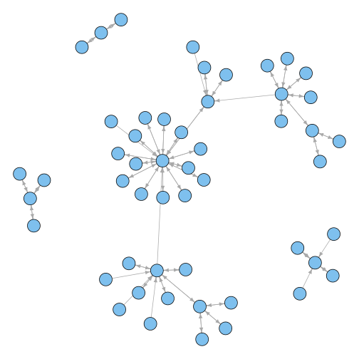

```r
# 데이터 프레임으로부터 방향이 있는 그래프 생성(Fruchterman-Reingold 알고리즘 사용)
g <- graph.data.frame(madmen2, directed=TRUE)
par(mar=c(0,0,0,0))   # 불필요한 여백을 제거
plot(g, layout=layout.fruchterman.reingold, vertex.size=8, edge.arrow.size=0.5,
     vertex.label=NA)
```

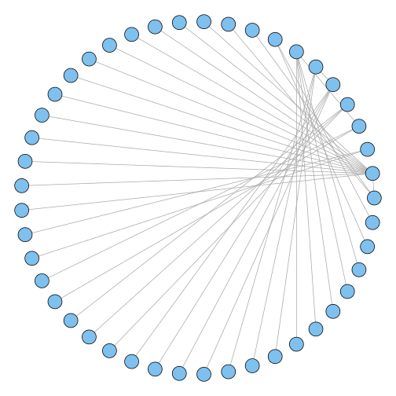

```r
# 데이터 프레임으로부터 방향이 없는 원형 그래프 생성
g <- graph.data.frame(madmen, directed=FALSE)
par(mar=c(0,0,0,0))  # 불필요한 여백을 제거
plot(g, layout=layout.circle, vertex.size=8, vertex.label=NA)
```

- igraph의 대안은 Rgraphviz로, 그래프 시각화 관련 오픈소스 라이브러리인  
  Graphviz의 프론트 엔드 버전이며 설치가 약간 까다롭다(Bioconductor저장소에서 구함)

### 13.5 네트워크 그래프에 텍스트 라벨 넣기

네트워크 그래프에서 텍스트 라벨을 사용하려면  
vertex.label에 이름으로 이루어진 벡터를 전달.

```r
library(igraph)
library(gcookbook)
# madmen을 복사한 뒤 한 행 걸러 선택
m <- madmen[1:nrow(madmen) %% 2 == 1, ]
g <- graph.data.frame(m, directed=FALSE)

# 각 노드의 이름을 출력
V(g)$name
```

```
##  [1] "Betty Draper"      "Don Draper"        "Harry Crane"
##  [4] "Joan Holloway"     "Lane Pryce"        "Peggy Olson"
##  [7] "Pete Campbell"     "Roger Sterling"    "Sal Romano"
## [10] "Henry Francis"     "Allison"           "Candace"
## [13] "Faye Miller"       "Megan Calvet"      "Rachel Menken"
## [16] "Suzanne Farrell"   "Hildy"             "Franklin"
## [19] "Rebecca Pryce"     "Abe Drexler"       "Duck Phillips"
## [22] "Playtex bra model" "Ida Blankenship"   "Mirabelle Ames"
## [25] "Vicky"             "Kitty Romano"
```

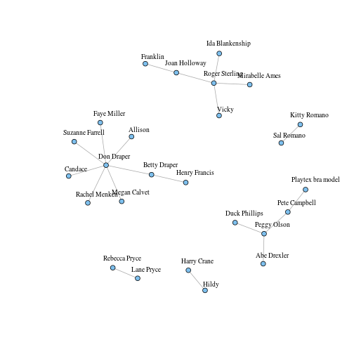

```r
plot(g, layout=layout.fruchterman.reingold,
     vertex.size        = 4,          # 노드 크기를 작게
     vertex.label       = V(g)$name,  # 라벨을 설정
     vertex.label.cex   = 0.8,        # 폰트 크기를 약간 작게
     vertex.label.dist  = 0.4,        # 라벨 위치 옮김
     vertex.label.color = "black")
```

값들을 plot() 에 인자로 전달하는 대신, plot() 객체를 수정해도 동일한 결과. 이를 위해 V()$xxx <- 를 사용.

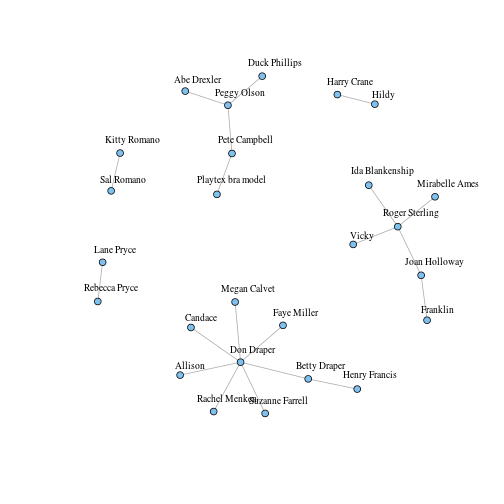

```r
# 다음 코드는 앞의 코드와 같은 그래프를 출력
V(g)$size        <- 4
V(g)$label       <- V(g)$name
V(g)$label.cex   <- 0.8
V(g)$label.dist  <- 0.4
V(g)$label.color <- "black"

# 그래프 전체의 속성을 설정
g$layout <- layout.fruchterman.reingold

plot(g)
```

마찬가지로 E() 함수를 쓰거나 edge.xxx 인자에 값을 전달하는 방법으로  
연결선의 속성도 설정할 수 있음.

```r
# 연결선 보기
E(g)
```

```
## Edge sequence:
##
## [1]  Henry Francis     -- Betty Draper
## [2]  Allison           -- Don Draper
## [3]  Don Draper        -- Betty Draper
## [4]  Candace           -- Don Draper
## [5]  Faye Miller       -- Don Draper
## [6]  Megan Calvet      -- Don Draper
## [7]  Rachel Menken     -- Don Draper
## [8]  Suzanne Farrell   -- Don Draper
## [9]  Hildy             -- Harry Crane
## [10] Franklin          -- Joan Holloway
## [11] Roger Sterling    -- Joan Holloway
## [12] Rebecca Pryce     -- Lane Pryce
## [13] Abe Drexler       -- Peggy Olson
## [14] Duck Phillips     -- Peggy Olson
## [15] Pete Campbell     -- Peggy Olson
## [16] Playtex bra model -- Pete Campbell
## [17] Ida Blankenship   -- Roger Sterling
## [18] Mirabelle Ames    -- Roger Sterling
## [19] Vicky             -- Roger Sterling
## [20] Kitty Romano      -- Sal Romano
```

[figure not shown]

```r
# 몇몇 라벨을  "M"으로 설정
E(g)[c(2,11,19)]$label <- "M"
plot(g)
```

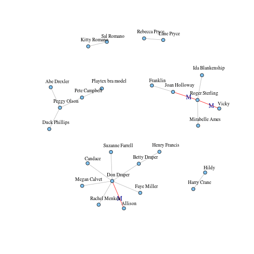

```r
# 모든 연결선을 회색으로 설정한 뒤 몇 개만 빨간색으로 변경
E(g)$color             <- "grey70"
E(g)[c(2,11,19)]$color <- "red"
plot(g)
```

# D. 히트맵(heatmap)

### 13.6 히트맵 생성하기

히트맵을 만들려면 geom_tile() 또는 geom_raster()를 사용하고 fill 에 연속변수를 대입.

```r
# 시계열 객체인 president 데이터 세트 사용
presidents
```

```
##      Qtr1 Qtr2 Qtr3 Qtr4
## 1945   NA   87   82   75
## 1946   63   50   43   32
## 1947   35   60   54   55
## 1948   36   39   NA   NA
## 1949   69   57   57   51
## 1950   45   37   46   39
## 1951   36   24   32   23
## 1952   25   32   NA   32
## 1953   59   74   75   60
## 1954   71   61   71   57
## 1955   71   68   79   73
## 1956   76   71   67   75
## 1957   79   62   63   57
## 1958   60   49   48   52
```

[output cut: 16 more lines]

```r
str(presidents)
```

```
##  Time-Series [1:120] from 1945 to 1975: NA 87 82 75 63 50 43 32 35 60 ...
```

```r
# ggplot()이 쓸 수 있는 형식으로 변환하기 위해 열에 수치형 값이 있는 데이터 프레임으로 바꿈
pres_rating <- data.frame(
    rating  = as.numeric(presidents),
    year    = as.numeric(floor(time(presidents))),
    quarter = as.numeric(cycle(presidents))
)

head(pres_rating, 10)
```

```
##    rating year quarter
## 1      NA 1945       1
## 2      87 1945       2
## 3      82 1945       3
## 4      75 1945       4
## 5      63 1946       1
## 6      50 1946       2
## 7      43 1946       3
## 8      32 1946       4
## 9      35 1947       1
## 10     60 1947       2
```

geom_tile()이나 geom_raster()로 히트맵 생성

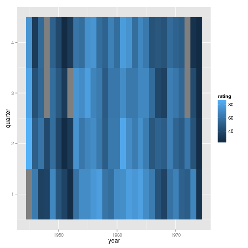

```r
# 기본 그래프
p <- ggplot(pres_rating, aes(x=year, y=quarter, fill=rating))

# geom_tile() 사용
p + geom_tile()
```

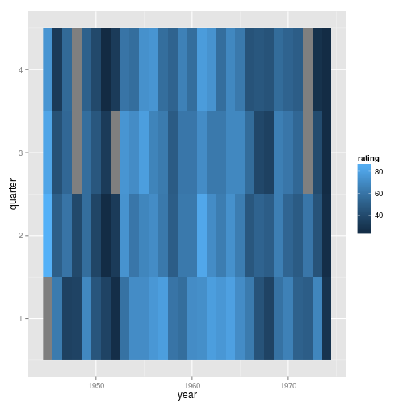

```r
# geom_raster() 사용(보기엔 똑같지만 조금 효율적)
p + geom_raster()
```

정보를 더 잘 전달하기 위해 히트맵의 외형을 변경

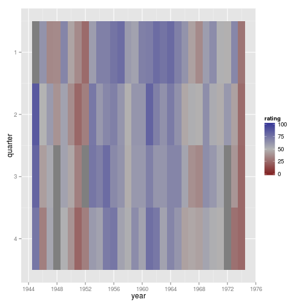

```r
# y축을 뒤집어 시간이 위에서 아래로 흐르도록 방향을 바꾸고
# x축을 따라 4년마다 눈금 표시를 집어넣어 대통령 임기와 일치시킴.
# 중간색/양끝색을 지정할 수 있는 scale_fill_gradient2()를 사용해 색상 척도 변경.
p + geom_tile() +
    scale_x_continuous(breaks = seq(1940, 1976, by = 4)) +
    scale_y_reverse() +
    scale_fill_gradient2(midpoint=50, mid="grey70", limits=c(0,100))
```

# E. 삼차원 산점도(3D scatterplot)

### 13.7 삼차원 산점도 생성하기

삼차원 산점도를 만들기 만들기 위해서 plot3D()와 같은 3D 그래픽스를 위한  
OpenGL 그래픽스 라이브러리 인터페이스를 제공하는 rgl패키지를 사용.

```r
# 패키지 설치
#install.packages("rgl")
library(rgl)
```

```r
### 3D 산점도 생성
### (기본은 사각형 점이므로 type="s"로 구형으로, size=0.75로 바꾸고, lit-FALSE로 조명 끔)
### 마우스로 이미지를 회전하거나, 휠로 줌인/줌아웃을 할 수 있음
plot3d(mtcars$wt, mtcars$disp, mtcars$mpg, type="s", size=0.75, lit=FALSE)
```

```
## Error: rgl.open failed
```

3D 산점도의 데이터를 더 이해하기 쉽게 도와주는 방법들

```r
### 두 벡터의 원소들을 사이사이에 끼워 넣기 위한 함수
interleave <- function(v1, v2)  as.vector(rbind(v1,v2))

### 점을 그래프로 그린다
plot3d(mtcars$wt, mtcars$disp, mtcars$mpg,
       xlab="Weight", ylab="Displacement", zlab="MPG",
       size=.75, type="s", lit=FALSE)
```

```
## Error: rgl.open failed
```

```r
### 선분을 추가한다
segments3d(interleave(mtcars$wt,   mtcars$wt),
           interleave(mtcars$disp, mtcars$disp),
           interleave(mtcars$mpg,  min(mtcars$mpg)),
           alpha=0.4, col="blue")
```

```
## Error: rgl.open failed
```

```r
### 축의 눈금 표시와 라벨 없이 그래프를 그린다
plot3d(mtcars$wt, mtcars$disp, mtcars$mpg,
       xlab = "", ylab = "", zlab = "",
       axes = FALSE,
       size=.75, type="s", lit=FALSE)
```

```
## Error: rgl.open failed
```

```r
segments3d(interleave(mtcars$wt,   mtcars$wt),
           interleave(mtcars$disp, mtcars$disp),
           interleave(mtcars$mpg,  min(mtcars$mpg)),
           alpha = 0.4, col = "blue")
```

```
## Error: rgl.open failed
```

```r
### 박스를 그린다
rgl.bbox(color="grey50",          # grey50 색 표면과 검은색 텍스트
         emission="grey50",       # 발광 색상은 grey50
         xlen=0, ylen=0, zlen=0)  # 눈금 표시를 넣지 않음
```

```
## Error: rgl_bbox
```

```r
### 앞으로 만들 모든 객체의 기본 색깔을 검은색으로 지정
rgl.material(color="black")

### 특정 면에만 축을 삽입. "x--", "x-+", "x+-", and "x++". 등의 값을 쓸 수 있다
axes3d(edges=c("x--", "y+-", "z--"),
       ntick=6,                       # 각 면에 6개의 눈금 표시를 넣게 시도한다
       cex=.75)                       # 폰트 크기를 줄인다
```

```
## Error: rgl.open failed
```

```r
### 축 라벨을 넣는다. 'line'은 라벨이 축에서 얼마나 멀리 떨어지는지를 지정한다
mtext3d("Weight",       edge="x--", line=2)
```

```
## Error: rgl.open failed
```

```r
mtext3d("Displacement", edge="y+-", line=3)
```

```
## Error: rgl.open failed
```

```r
mtext3d("MPG",          edge="z--", line=3)
```

```
## Error: rgl.open failed
```

### 13.8 삼차원 그래프에 예측면 추가하기

삼차원 산점도에 예측한 값들로 이루어진 표면을 추가하기

```r
### 모형이 주어지면 xvar와 yvar를 가지고 zvar를 예측
### x와 y 변수 범위와 16X16 격자를 기본 값으로 한다
predictgrid <- function(model, xvar, yvar, zvar, res = 16, type = NULL) {
  # 예측 변수의 범위를 찾는다. lm과 glm, 그리고 몇 가지 다른 객체에 작동하지만
  # 다른 객체에 대해서는 코드의 변경이 필요할 수 있다
  xrange <- range(model$model[[xvar]])
  yrange <- range(model$model[[yvar]])

  newdata <- expand.grid(x = seq(xrange[1], xrange[2], length.out = res),
                         y = seq(yrange[1], yrange[2], length.out = res))
  names(newdata) <- c(xvar, yvar)
  newdata[[zvar]] <- predict(model, newdata = newdata, type = type)
  newdata
}


### x, y, z 변수들이 길게 든 데이터 프레임을
### x와 y를 행/열 값으로 하는 리스트 하나로 변환, z를 행렬로 변환한다
df2mat <- function(p, xvar = NULL, yvar = NULL, zvar = NULL) {
  if (is.null(xvar)) xvar <- names(p)[1]
  if (is.null(yvar)) yvar <- names(p)[2]
  if (is.null(zvar)) zvar <- names(p)[3]

  x <- unique(p[[xvar]])
  y <- unique(p[[yvar]])
  z <- matrix(p[[zvar]], nrow = length(y), ncol = length(x))

  m <- list(x, y, z)
  names(m) <- c(xvar, yvar, zvar)
  m
}

### 두 벡터의 원소들을 사이사이에 끼워 넣기 위한 함수
interleave <- function(v1, v2)  as.vector(rbind(v1,v2))
```

이러한 유틸리티 함수들을 정의한 다음, surface3d() 함수를 사용해서  
데이터로부터 선형 모형을 만들고 이것을 데이터와 함께 그물망(mesh) 형태로 그래프에 넣을 수 있다

```r
library(rgl)

### 데이터 세트의 복사본을 만든다
m <- mtcars

### 선형 모형을 생성한다
mod <- lm(mpg ~ wt + disp + wt:disp, data = m)

### wt와 disp로부터 mpg 값을 예측한다
m$pred_mpg <- predict(mod)

### wt와 disp 격자로부터 예측된 mpg를 구한다
mpgrid_df <- predictgrid(mod, "wt", "disp", "mpg")
mpgrid_list <- df2mat(mpgrid_df)

### 데이터 점들을 가지고 그래프를 그린다
plot3d(m$wt, m$disp, m$mpg, type="s", size=0.5, lit=FALSE)
```

```
## Error: rgl.open failed
```

```r
### 상응하는 예측 점들을 넣는다(더 작은 크기로)
spheres3d(m$wt, m$disp, m$pred_mpg, alpha=0.4, type="s", size=0.5, lit=FALSE)
```

```
## Error: rgl.open failed
```

```r
### 오차를 보여주는 선분을 추가한다
segments3d(interleave(m$wt,   m$wt),
           interleave(m$disp, m$disp),
           interleave(m$mpg,  m$pred_mpg),
           alpha=0.4, col="red")
```

```
## Error: rgl.open failed
```

```r
### 예측 값으로 만든 메시를 추가한다
surface3d(mpgrid_list$wt, mpgrid_list$disp, mpgrid_list$mpg,
          alpha=0.4, front="lines", back="lines")
```

```
## Error: rgl.open failed
```

그래프 외형에 변화를 줄 수 있다.

```r
plot3d(mtcars$wt, mtcars$disp, mtcars$mpg,
       xlab = "", ylab = "", zlab = "",
       axes = FALSE,
       size=.5, type="s", lit=FALSE)
```

```
## Error: rgl.open failed
```

```r
### 상응하는 예측점들을 넣는다(더 작은 크기로)
spheres3d(m$wt, m$disp, m$pred_mpg, alpha=0.4, type="s", size=0.5, lit=FALSE)
```

```
## Error: rgl.open failed
```

```r
### 오차를 보여주는 선분을 추가한다
segments3d(interleave(m$wt,   m$wt),
           interleave(m$disp, m$disp),
           interleave(m$mpg,  m$pred_mpg),
           alpha=0.4, col="red")
```

```
## Error: rgl.open failed
```

```r
### 예측 값으로 만든 메시를 추가한다
surface3d(mpgrid_list$wt, mpgrid_list$disp, mpgrid_list$mpg,
          alpha=0.4, front="lines", back="lines")
```

```
## Error: rgl.open failed
```

```r
### 박스를 그린다
rgl.bbox(color="grey50",          # grey60 surface and black text
         emission="grey50",       # emission color is grey50
         xlen=0, ylen=0, zlen=0)  # Don't add tick marks
```

```
## Error: rgl_bbox
```

```r
### 앞으로 만들 모든 객체의 기본 색깔을 검은색으로 지정
rgl.material(color="black")

### 특정 면에만 축을 삽입.  "x--", "x-+", "x+-", and "x++". 등의 값을 쓸 수 있다
axes3d(edges=c("x--", "y+-", "z--"),
       ntick=6,                       # 각 면에 6개의 눈금 표시를 넣게 시도한다
       cex=.75)                       # 폰트 크기를 줄인다
```

```
## Error: rgl.open failed
```

```r
### 축 라벨을 넣는다. 'line'은 라벨이 축에서 얼마나 멀리 떨어지는지를 지정한다
mtext3d("Weight",       edge="x--", line=2)
```

```
## Error: rgl.open failed
```

```r
mtext3d("Displacement", edge="y+-", line=3)
```

```
## Error: rgl.open failed
```

```r
mtext3d("MPG",          edge="z--", line=3)
```

```
## Error: rgl.open failed
```

### 13.9 삼차원 그래프 저장하기

rgl 패키지로 생성한 삼차원 그래프를 저장한다

```r
### rgl 로 만든 비트맵 그래프 이미지를 저장하기 위해  rgl.snapshot()을 사용한다
library(rgl)
plot3d(mtcars$wt, mtcars$disp, mtcars$mpg, type="s", size=0.75, lit=FALSE)
```

```
## Error: rgl.open failed
```

```r
rgl.snapshot('3dplot.png', fmt='png')
```

```
## Error: failed
```

```r
### rgl.postscript()를 사용해서 postscript 또는 PDF 파일로 저장해도 된다
rgl.postscript('figs/miscgraph/3dplot.pdf', fmt='pdf')
rgl.postscript('figs/miscgraph/3dplot.ps', fmt='ps')
```

출력을 반복 가능하게 만들기 위해 현재 시점을 저장한 뒤 추후 복원할 수도 있다

```r
### 현재 시점을 저장
view <- par3d("userMatrix")
```

```
## Error: rgl.open failed
```

```r
### 저장된 시점을 복원
par3d(userMatrix = view)
```

```
## Error: object 'view' not found
```

```r
### 스크립트에 view를 저장하려면  dput()을 사용한 다음 출력된 결과를 스크립트에 복사해서 붙어넣는
dput(view)
```

```
## Error: object 'view' not found
```

```r
structure(c(0.907931625843048, 0.267511069774628, -0.322642296552658,
0, -0.410978674888611, 0.417272746562958, -0.810543060302734,
0, -0.0821993798017502, 0.868516683578491, 0.488796472549438,
0, 0, 0, 0, 1), .Dim = c(4L, 4L))
```

```
##         [,1]    [,2]    [,3] [,4]
## [1,]  0.9079 -0.4110 -0.0822    0
## [2,]  0.2675  0.4173  0.8685    0
## [3,] -0.3226 -0.8105  0.4888    0
## [4,]  0.0000  0.0000  0.0000    1
```

```r
### userMatrix의 텍스트 표현을 얻었으면, 다음 코드를 스크립트에 추가한다
view <- structure(c(0.907931625843048, 0.267511069774628, -0.322642296552658,
0, -0.410978674888611, 0.417272746562958, -0.810543060302734,
0, -0.0821993798017502, 0.868516683578491, 0.488796472549438,
0, 0, 0, 0, 1), .Dim = c(4L, 4L))

par3d(userMatrix = view)
```

```
## Error: rgl.open failed
```

### 13.10 삼차원 그래프에 애니메이션 넣기

삼차원 그래프의 시점을 회전시키는 애니메이션을 넣으려면 spin3d()와 함께 play3d()를 사용한다

```r
library(rgl)
plot3d(mtcars$wt, mtcars$disp, mtcars$mpg, type="s", size=0.75, lit=FALSE)
```

```
## Error: rgl.open failed
```

```r
play3d(spin3d())
```

```
## Error: rgl.open failed
```

기본 설정으로, R에 커맨드를 입력하기 전까지 그래프는 z(수직)를 기준으로 회전한다.  
회전 축과 회전 속도, 지속 시간은 조절할 수 있다

```r
### 4rpm으로 20초 동안 x축 회전
play3d(spin3d(axis=c(1,0,0), rpm=4), duration=20)
```

```
## Error: rgl.open failed
```

동영상을 저장하려면 movie3d() 함수를 사용한다. 이 함수는 프레임마다 .png 파일들을 연속으로 생성하며 ImageMagick이라는 이미지 유틸리티의  
convert 프로그램을 사용해서 이 파일들을 하나의 .gif 파일로 합쳐 준다.

```r
### 4rpm으로 15초 동안 z 축 회전
movie3d(spin3d(axis=c(0,0,1), rpm=4), duration=15, fps=50)
```

```
## Error: rgl.open failed
```

출력된 파일은 임시 디렉터리에 저장되며, 이름은 R콘솔에 출력된다.

# F. 덴드로그램(dendrogram)

### 13.11 덴드로그램 생성하기

항목들이 어떻게 군집(cluster)으로 나뉘어 있는지 보여주기 위해 덴드로그램을 만들려면,  
hclust()를 사용한 다음 이 결과물을 가지고 그래프를 그리는데 데이터 처리에 시간이 걸릴 수 있다

```r
library(gcookbook)

# 2009년의 데이터를 가져온다.
c2 <- subset(countries, Year==2009)

# 결측치가 들어간 행들을 누락시킨다.
c2 <- c2[complete.cases(c2), ]

# 랜덤으로 25개의 국가를 고른다.(추후 반복 가능하도록 랜덤 시드를 설정한다)
set.seed(201)
c2 <- c2[sample(1:nrow(c2), 25), ]

c2
```

```
##                   Name Code Year     GDP laborrate healthexp infmortality
## 6731          Mongolia  MNG 2009  1690.4      72.9     74.20         27.8
## 1733            Canada  CAN 2009 39599.0      67.8   4379.76          5.2
## 4028         Guatemala  GTM 2009  2685.0      66.9    186.12         25.9
## 611            Austria  AUT 2009 45555.4      60.4   5037.31          3.6
## 10964           Zambia  ZMB 2009  1006.4      69.2     47.06         71.5
## 1478          Bulgaria  BGR 2009  6403.1      54.5    474.85         11.1
## 662         Azerbaijan  AZE 2009  4808.2      63.0    284.73         41.1
## 3824            Greece  GRC 2009 28936.5      53.7   3040.73          3.5
## 1070             Benin  BEN 2009   771.7      72.7     31.93         74.7
## 2957  Egypt, Arab Rep.  EGY 2009  2370.7      48.8    113.30         20.0
## 4844             Italy  ITA 2009 35073.3      49.1   3327.63          3.2
## 7037             Nepal  NPL 2009   438.2      71.5     25.34         43.3
## 6119          Malaysia  MYS 2009  6908.7      62.0    336.44          5.6
## 4793            Israel  ISR 2009 26102.4      57.1   1966.47          3.7
## 5252       Korea, Rep.  KOR 2009 17110.0      60.9   1107.95          4.3
## 5099             Kenya  KEN 2009   744.4      82.2     33.25         56.3
## 152            Algeria  DZA 2009  4022.2      58.5    267.95         32.0
## 2447           Croatia  HRV 2009 14322.6      53.0   1120.37          4.9
## 5609           Lesotho  LSO 2009   800.4      74.0     70.05         67.0
## 4691           Ireland  IRL 2009 49737.9      63.6   4951.84          3.4
## 7343           Nigeria  NGA 2009  1091.1      56.2     69.30         90.4
## 5660           Liberia  LBR 2009   229.3      71.1     29.36         77.6
## 5558           Lebanon  LBN 2009  8321.4      46.1    663.27         19.4
## 5966    Macedonia, FYR  MKD 2009  4510.2      54.0    313.69         10.6
## 10148     Turkmenistan  TKM 2009  3710.5      68.0     77.07         48.0
```

```r
# 행 이름을 설정하고, 군집화에 사용되지 않는 Name, Code, Year 열을 제외시킨다.
rownames(c2) <- c2$Name
c2 <- c2[,4:7]
c2
```

```
##                      GDP laborrate healthexp infmortality
## Mongolia          1690.4      72.9     74.20         27.8
## Canada           39599.0      67.8   4379.76          5.2
## Guatemala         2685.0      66.9    186.12         25.9
## Austria          45555.4      60.4   5037.31          3.6
## Zambia            1006.4      69.2     47.06         71.5
## Bulgaria          6403.1      54.5    474.85         11.1
## Azerbaijan        4808.2      63.0    284.73         41.1
## Greece           28936.5      53.7   3040.73          3.5
## Benin              771.7      72.7     31.93         74.7
## Egypt, Arab Rep.  2370.7      48.8    113.30         20.0
## Italy            35073.3      49.1   3327.63          3.2
## Nepal              438.2      71.5     25.34         43.3
## Malaysia          6908.7      62.0    336.44          5.6
## Israel           26102.4      57.1   1966.47          3.7
## Korea, Rep.      17110.0      60.9   1107.95          4.3
## Kenya              744.4      82.2     33.25         56.3
## Algeria           4022.2      58.5    267.95         32.0
## Croatia          14322.6      53.0   1120.37          4.9
## Lesotho            800.4      74.0     70.05         67.0
## Ireland          49737.9      63.6   4951.84          3.4
## Nigeria           1091.1      56.2     69.30         90.4
## Liberia            229.3      71.1     29.36         77.6
## Lebanon           8321.4      46.1    663.27         19.4
## Macedonia, FYR    4510.2      54.0    313.69         10.6
## Turkmenistan      3710.5      68.0     77.07         48.0
```

```r
# infmortality의 효과는 GDP에 비해 무시할 만큼 작으므로, 데이터를 비교가능하게 확대/축소한다.
# scale() 함수는 기본적으로 각 열을 자신의 표준 편차에 비례하게 맞춤으로써 정규화한다.
c3 <- scale(c2)
c3
```

```
##                      GDP laborrate  healthexp infmortality
## Mongolia         -0.6783   1.15029 -0.6341394     -0.08335
## Canada            1.7505   0.59747  1.9736220     -0.88015
## Guatemala        -0.6146   0.49992 -0.5663495     -0.15033
## Austria           2.1321  -0.20465  2.3718821     -0.93656
## Zambia           -0.7222   0.74923 -0.6505785      1.45737
## Bulgaria         -0.3764  -0.84418 -0.3914778     -0.67213
## Azerbaijan       -0.4786   0.07718 -0.5066289      0.38557
## Greece            1.0673  -0.93090  1.1626100     -0.94009
## Benin            -0.7372   1.12861 -0.6597408      1.57019
## Egypt, Arab Rep. -0.6348  -1.46203 -0.6104582     -0.35835
## Italy             1.4605  -1.42951  1.3363751     -0.95066
## Nepal            -0.7586   0.99853 -0.6637287      0.46313
## Malaysia         -0.3440  -0.03122 -0.4753076     -0.86605
## Israel            0.8857  -0.56235  0.5119590     -0.93303
## Korea, Rep.       0.3096  -0.15045 -0.0080252     -0.91188
## Kenya            -0.7390   2.15836 -0.6589411      0.92147
## Algeria          -0.5289  -0.41060 -0.5167913      0.06473
## Croatia           0.1310  -1.00677 -0.0005011     -0.89073
## Lesotho          -0.7354   1.26952 -0.6366519      1.29872
## Ireland           2.4001   0.14221  2.3201175     -0.94361
## Nigeria          -0.7167  -0.65991 -0.6371077      2.12372
## Liberia          -0.7720   0.95518 -0.6612990      1.67244
## Lebanon          -0.2535  -1.75470 -0.2773526     -0.37950
## Macedonia, FYR   -0.4977  -0.89838 -0.4890859     -0.68976
## Turkmenistan     -0.5489   0.61915 -0.6324003      0.62884
## attr(,"scaled:center")
##          GDP    laborrate    healthexp infmortality
##     12277.96        62.29      1121.20        30.16
## attr(,"scaled:scale")
##          GDP    laborrate    healthexp infmortality
##    15607.853        9.226     1651.057       28.363
```

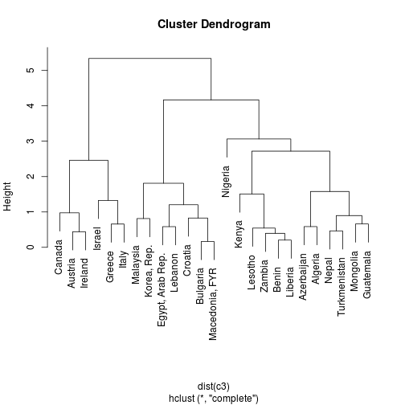

```r
# hclust() 함수는 여러 가지 군집 분석 방식을 제공한다.
# 기본은 'complete'이고, 그외 'ward', 'single', 'average', 'mcquitty', 'centroid' 등이 있다.
hc <- hclust(dist(c3))

# 덴드로그램을 만든다.
plot(hc)
```

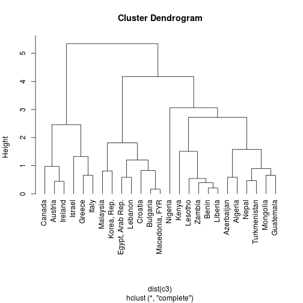

```r
# 텍스트를 정렬한다
plot(hc, hang = -1)
```

# G. 벡터장(vector field)

### 13.12 벡터장 그리기

벡터장(vector field)를 만들려면 geom_segment() 를 사용한다.

```r
library(gcookbook)
head(isabel, 10)
```

```
##      x     y     z vx vy vz  t speed
## 1  -83 41.70 0.035 NA NA NA NA    NA
## 2  -83 41.56 0.035 NA NA NA NA    NA
## 3  -83 41.41 0.035 NA NA NA NA    NA
## 4  -83 41.27 0.035 NA NA NA NA    NA
## 5  -83 41.12 0.035 NA NA NA NA    NA
## 6  -83 40.98 0.035 NA NA NA NA    NA
## 7  -83 40.83 0.035 NA NA NA NA    NA
## 8  -83 40.69 0.035 NA NA NA NA    NA
## 9  -83 40.55 0.035 NA NA NA NA    NA
## 10 -83 40.40 0.035 NA NA NA NA    NA
```

```r
tail(isabel, 10)
```

```
##             x     y     z     vx     vy        vz      t speed
## 156241 -62.13 25.11 18.04 -12.92 -5.635 -0.085394 -67.22 14.10
## 156242 -62.13 24.96 18.04 -12.82 -5.611 -0.098288 -67.15 14.00
## 156243 -62.13 24.82 18.04 -12.69 -5.539 -0.090923 -67.08 13.84
## 156244 -62.13 24.67 18.04 -12.46 -5.471 -0.056029 -67.02 13.61
## 156245 -62.13 24.53 18.04 -12.14 -5.420 -0.022862 -67.00 13.30
## 156246 -62.13 24.39 18.04 -11.76 -5.391 -0.006700 -67.01 12.94
## 156247 -62.13 24.24 18.04 -11.52 -5.386 -0.006834 -67.01 12.72
## 156248 -62.13 24.10 18.04 -11.40 -5.315  0.009657 -67.00 12.58
## 156249 -62.13 23.95 18.04 -11.38 -5.275  0.040922 -67.00 12.54
## 156250 -62.13 23.81 18.04 -12.17 -5.436  0.030216 -66.98 13.33
```

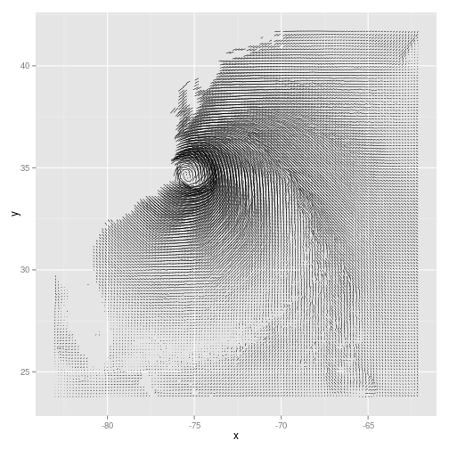

```r
# x : 경도, y : 위도, z : 높이(단위 km)
# vx, vy, vz : 각 방향들의 풍속 성분(component)(단위 m/s)

# x와 y 값을 각 선분의 시작점으로 준 다음, vx 와 vy 값의 일부를 더해 각 선분의 끝점을 얻는다.
islice <- subset(isabel, z == min(z))

ggplot(islice, aes(x=x, y=y)) +
       geom_segment(aes(xend = x + vx/50, yend = y + vy/50),
                    size = 0.25)   # 선분을 0.25mm 두께로 만든다.
```

데이터가 너무 고해상도라서 읽기 힘들고,  
선분에 화살표 머리가 없어 흐름의 방향을 보여주지 못한다는 문제를 해결한다.

(1) every_n()이라는 함수를 정의해 매 n개의 값들 중 하나만 유지하고 나머지는 제외시킨다.

```r
# 전체 z중 z가 최솟값인 데이터만 추린다.
islice <- subset(isabel, z == min(z))

# 벡터  x 에서 'by' 값만큼의 개수 중 하나씩만을 유지한다.
every_n <- function(x, by = 2) {
    x <- sort(x)
    x[seq(1, length(x), by = by)]
}

# x와 y에서 매 4 값마다 1개만 유지한다.
keepx <- every_n(unique(isabel$x), by=4)
keepy <- every_n(unique(isabel$y), by=4)

# x 값이 keepx에 들어 있고, y 값이 keepy에 들어 있는 행들만 유지한다.
islicesub <- subset(islice, x %in% keepx  &  y %in% keepy)
```

(2) 화살표 머리를 추가하여 그래프를 그린다.

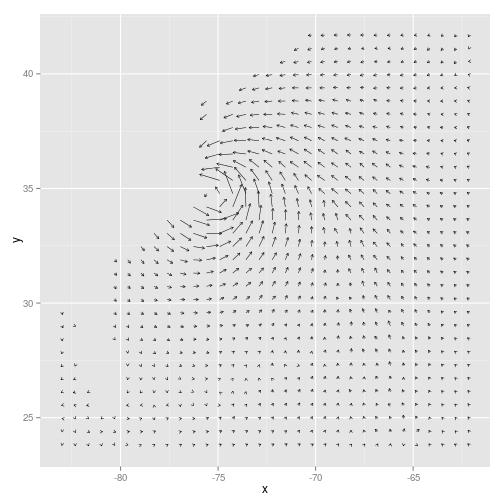

```r
# arrow() 항수를 위해  grid를 로딩한다.
#install.packages("grid")
library(grid)

# 데이터 부분 집합을 가지고 0.1cm 길이의 화살표를 넣은 그래프를 만든다.
ggplot(islicesub, aes(x=x, y=y)) +
    geom_segment(aes(xend = x+vx/50, yend = y+vy/50),
                 arrow = arrow(length = unit(0.1, "cm")), size = 0.25)
```

데이터 해석을 왜곡시키는 효과를 완화하도록 다른 속성들에도 속도를 대입한다. 여기서는 speed를 alpha에 대입해본다.

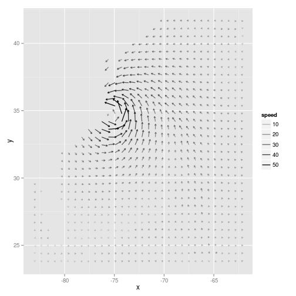

```r
# 현재 'speed' 열에 z 성분이 포함되어 있으므로, 수평 속도인  speedxy를 계산한다.
islicesub$speedxy <- sqrt(islicesub$vx^2 + islicesub$vy^2)

# speed를 alpha에 대입한다.
ggplot(islicesub, aes(x=x, y=y)) +
    geom_segment(aes(xend = x+vx/50, yend = y+vy/50, alpha = speed),
                 arrow = arrow(length = unit(0.1,"cm")), size = 0.6)
```

미국 지도를 추가하고, 관심 있는 지역으로 줌인해 보자.

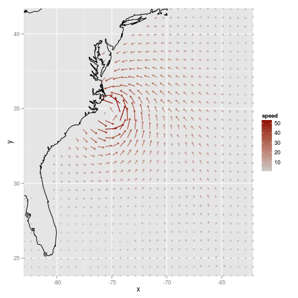

```r
# 미국 지도 데이터를 가져온다.
usa <- map_data("usa")
# 에러: 함수 "map_data"를 찾을 수 없습니다

# speed를 colour에 대입하고, "grey80"부터 "darkred"까지로 색상을 설정한다.
ggplot(islicesub, aes(x=x, y=y)) +
    geom_segment(aes(xend = x+vx/50, yend = y+vy/50, colour = speed),
                 arrow = arrow(length = unit(0.1,"cm")), size = 0.6) +
    scale_colour_continuous(low="grey80", high="darkred") +
    geom_path(aes(x=long, y=lat, group=group), data=usa) +
    coord_cartesian(xlim = range(islicesub$x), ylim = range(islicesub$y))
```

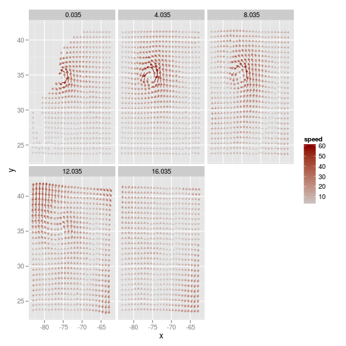

```r
# x와 y에서 5개의 값마다 하나씩만 유지하고, z에서는 2개의 값마다 하나씩만 유지한다.
keepx <- every_n(unique(isabel$x), by=5)
keepy <- every_n(unique(isabel$y), by=5)
keepz <- every_n(unique(isabel$z), by=2)

isub <- subset(isabel, x %in% keepx  &  y %in% keepy  &  z %in% keepz)

ggplot(isub, aes(x=x, y=y)) +
    geom_segment(aes(xend = x+vx/50, yend = y+vy/50, colour = speed),
                 arrow = arrow(length = unit(0.1,"cm")), size = 0.5) +
    scale_colour_continuous(low="grey80", high="darkred") +
    facet_wrap( ~ z)
```